# AquaMaps vs AquaX vs OBIS-SDM — side-by-side examples

Habitat suitability in US waters: AquaMaps 1.0 (v8 input), AquaX (v9 input), OBIS-SDM (v11 candidate), and their differences

Published

2026-09-15

> **Not a pipeline stage** — a standalone report rendered from the v9 ingest outputs (`dist/dataset=ax`, `dist/dataset=am`) plus the public OBIS-SDM COGs, for review conversations. The systematic per-species AquaX-vs-AquaMaps comparison (every superseded taxon × subregion, the 20 least / most different) is in `ingest_aquax.html`; the OBIS-SDM coverage numbers are in `explore_obis-sdm.html`. This page just draws a few species so the *kind* of difference is visible.

**How to read a species.** Top row, left to right: AquaMaps 1.0’s 0.5° suitability bilinearly interpolated to the 0.05° grid (the v8 input); AquaX’s ensemble suitability delivered on that grid (÷10 to the same 0–100 scale; pixels below 1 dropped, as for AquaMaps); OBIS-SDM’s ensemble median (MPA Europe v2, predicted globally on the same grid; the species’ single published algorithm where no ensemble exists) kept where it is ≥ the model’s own **minimum training presence** threshold (`mtp`, the lowest suitability at any record used to fit it — the plan’s default ingest threshold). Bottom row: the pairwise differences on shared cells (blue = the later model lower, red = higher): AquaX − AquaMaps is the *improvement* AquaX brought; OBIS − AquaMaps the improvement OBIS-SDM would bring; OBIS − AquaX the *agreement* between the two modern models. All three are shown only inside the AquaX mask (US waters). Numbers under each species are computed on the shared cells. Species with no OBIS-SDM keep the v9 row.

```r
librarian::shelf(arrow, DBI, dplyr, duckdb, fs, ggplot2, glue, here, knitr, patchwork, readr,
                 rnaturalearth, sf, terra, tidyterra, tibble, quiet = TRUE)
source(here("libs/paths.R"))
dir_atlas <- path.expand(glue("{dir_big_v}/marine-atlas"))
dir_ax <- glue("{dir_atlas}/dist/dataset=ax"); dir_am <- glue("{dir_atlas}/dist/dataset=am")
stopifnot(dir_exists(dir_ax), dir_exists(dir_am), file_exists(glue("{dir_atlas}/dist/ax_mask.parquet")))

# OBIS-SDM (MPA Europe v2): public bucket; per-species files cached under raw/obis-maps/taxonid={AphiaID}
obis_s3     <- "https://obis-maps.s3.amazonaws.com/sdm/species"
dir_obismap <- path.expand(glue("{dir_raw}/obis-maps")); dir_create(dir_obismap)
aws_zip     <- glue("{dir_obismap}/aws_files_list.zip")
if (!file_exists(aws_zip)) download.file("https://github.com/iobis/mpaeu_sdm/raw/main/aws_files_list.zip", aws_zip, quiet = TRUE)
if (!file_exists(glue("{dir_obismap}/species_files.parquet"))) unzip(aws_zip, exdir = dir_obismap)
obis_sf <- read_parquet(glue("{dir_obismap}/species_files.parquet"))   # taxonid, fit_n, available_models

# species to show (scientific names; resolved to AphiaID through the WoRMS snapshot)
species <- c(
  "Megaptera novaeangliae",     # humpback whale
  "Caretta caretta",            # loggerhead turtle
  "Gadus morhua",               # Atlantic cod
  "Thunnus thynnus",            # Atlantic bluefin tuna
  "Hippoglossus stenolepis",    # Pacific halibut
  "Lutjanus campechanus",       # red snapper
  "Homarus americanus",         # American lobster
  "Acropora palmata",           # elkhorn coral
  "Tmetonyx cicada",            # an amphipod: among the MOST changed in the 50-model smoke test
  "Acanthostepheia malmgreni",  # an amphipod: among the LEAST changed in the smoke test
  "Odobenus rosmarus")          # walrus that previously had overextended range into Gulf

con <- dbConnect(duckdb())
dbExecute(con, glue("ATTACH '{path.expand(spp_db)}' AS spp (READ_ONLY)"))
```

```
[1] 0
```

```r
ax_ids <- read_csv(glue("{dir_atlas}/dist/ax_stats.csv"), show_col_types = FALSE, col_types = cols(sp_id = "c"))$sp_id
duckdb_register(con, "want", tibble(scientific_name = species))
duckdb_register(con, "ax_ids", tibble(sp_id = ax_ids))
sp <- dbGetQuery(con, "
  SELECT w.scientific_name, CAST(x.scientificNameID AS VARCHAR) AS sp_id, x.\"class\" AS cls
  FROM want w JOIN spp.worms x ON x.scientificName = w.scientific_name
  JOIN ax_ids a ON a.sp_id = CAST(x.scientificNameID AS VARCHAR)
  WHERE x.taxonomicStatus = 'accepted'") |> distinct(scientific_name, .keep_all = TRUE)
missing <- setdiff(species, sp$scientific_name)
if (length(missing)) message("not in AquaX (or not an accepted WoRMS name): ", paste(missing, collapse = ", "))

# AquaMaps models for the same taxa: v8's published taxon_model (mdl_key am|... -> WoRMS id)
prev_tm <- read_parquet(glue("{dir_big}/{ver_prev}/marine-atlas/tables/taxon_model.parquet")) |>
  filter(ds_key == "am", taxon_authority == "worms") |> transmute(sp_id = as.character(taxon_id), am_key = mdl_key)
sp <- sp |> left_join(prev_tm |> group_by(sp_id) |> summarise(am_keys = list(am_key), .groups = "drop"), by = "sp_id")

# OBIS-SDM: which published method to draw (ensemble median > esm > the single algorithm)
obis_method <- function(taxonid) {
  m <- obis_sf |> filter(taxonid == !!as.integer(taxonid)) |> pull(available_models)
  if (!length(m)) return(NA_character_)
  m <- m[[1]]$method
  pref <- c("ensemble", "esm", "maxent", "rf", "xgboost")
  pref[pref %in% m][1]
}
sp <- sp |> mutate(ob_method = vapply(sp_id, obis_method, character(1)),
                   ob_fit_n  = obis_sf$fit_n[match(as.integer(sp_id), obis_sf$taxonid)])
dbExecute(con, glue("CREATE TABLE ax_mask AS SELECT cell_id FROM read_parquet('{dir_atlas}/dist/ax_mask.parquet')"))
```

```
[1] 641651
```

```r
mask_ids <- dbGetQuery(con, "SELECT cell_id FROM ax_mask")$cell_id
land <- ne_countries(scale = "medium", returnclass = "sf")
grid <- msens::grid_spec_for("global05")
kable(sp |> mutate(n_am_models = lengths(am_keys)) |> select(scientific_name, sp_id, cls, n_am_models, ob_method, ob_fit_n),
      caption = "ob_method = OBIS-SDM surface drawn (NA = no OBIS-SDM for this species); ob_fit_n = its fit points")
```

ob_method = OBIS-SDM surface drawn (NA = no OBIS-SDM for this species); ob_fit_n = its fit points

| scientific_name | sp_id | cls | n_am_models | ob_method | ob_fit_n |
| --- | --- | --- | --- | --- | --- |
| Gadus morhua | 126436 | Teleostei | 1 | ensemble | 2092 |
| Acropora palmata | 288227 | Hexacorallia | 1 | NA | NA |
| Thunnus thynnus | 127029 | Teleostei | 1 | ensemble | 2653 |
| Lutjanus campechanus | 159795 | Teleostei | 1 | NA | NA |
| Hippoglossus stenolepis | 274290 | Teleostei | 1 | NA | NA |
| Acanthostepheia malmgreni | 102864 | Malacostraca | 1 | ensemble | 168 |
| Caretta caretta | 137205 | NA | 1 | ensemble | 1160 |
| Homarus americanus | 156134 | Malacostraca | 1 | ensemble | 242 |
| Odobenus rosmarus | 137077 | Mammalia | 1 | ensemble | 1257 |
| Megaptera novaeangliae | 137092 | Mammalia | 1 | ensemble | 4045 |
| Tmetonyx cicada | 102736 | Malacostraca | 1 | ensemble | 1323 |

```r
# (cell_id, val) -> SpatRaster on the global grid, cropped to a bbox given as cell-id extents
cells_to_rast <- function(d, bb) {
  r <- rast(nrows = bb$r1 - bb$r0 + 1, ncols = bb$c1 - bb$c0 + 1,
            xmin = grid$xmin + (bb$c0 - 1) * grid$resx, xmax = grid$xmin + bb$c1 * grid$resx,
            ymin = grid$ymax - bb$r1 * grid$resy,       ymax = grid$ymax - (bb$r0 - 1) * grid$resy,
            crs = "EPSG:4326")
  row <- (d$cell_id - 1) %/% grid$nc + 1; col <- (d$cell_id - 1) %% grid$nc + 1
  v <- rep(NA_real_, ncell(r)); v[(row - bb$r0) * ncol(r) + (col - bb$c0) + 1] <- d$val
  r[] <- v; r
}

# OBIS-SDM current surface for one species as (cell_id, val) inside the AquaX mask, >= its mtp threshold
obis_cells <- function(taxonid, method) {
  if (is.na(method)) return(NULL)
  file_method <- c(ensemble = "ensemble", esm = "esm", maxent = "maxent", rf = "rf_classification_ds", xgboost = "xgboost")[[method]]
  d <- glue("{dir_obismap}/taxonid={taxonid}"); dir_create(d)
  get <- function(rel, f) { p <- glue("{d}/{f}")
    if (!file_exists(p)) download.file(glue("{obis_s3}/taxonid={taxonid}/model=mpaeu/{rel}"), p, quiet = TRUE, mode = "wb"); p }
  f_tif <- get(glue("predictions/taxonid={taxonid}_model=mpaeu_method={file_method}_scen=current_cog.tif"), glue("{file_method}_current.tif"))
  f_thr <- get(glue("metrics/taxonid={taxonid}_model=mpaeu_what=thresholds.parquet"), "thresholds.parquet")
  r <- rast(f_tif)
  stopifnot(ncol(r) == grid$nc, nrow(r) == grid$nr, max(abs(as.vector(ext(r)) - c(-180, 180, -90, 90))) < 1e-4)
  thr <- read_parquet(f_thr); mtp <- thr$mtp[thr$model == method]
  if (!length(mtp) || is.na(mtp)) mtp <- 0.01
  v <- values(r[[1]])[mask_ids, 1]   # the pixel index IS cell_id on global05 (asserted above)
  tibble(cell_id = mask_ids, val = as.numeric(v)) |> filter(!is.na(val), val >= mtp * 100) |>
    structure(mtp = mtp * 100, method = method)
}

pair_stats <- function(a, b, sfx) {
  both <- inner_join(a, b, by = "cell_id", suffix = c("_a", "_b"))
  tibble(n_shared = nrow(both), jaccard = round(nrow(both) / length(union(a$cell_id, b$cell_id)), 2),
         mean_a = round(mean(both$val_a), 1), mean_b = round(mean(both$val_b), 1),
         delta = round(mean(both$val_b - both$val_a), 1),
         cor = round(suppressWarnings(cor(both$val_a, both$val_b)), 2)) |>
    rename_with(~ paste0(.x, "_", sfx))
}

species_panels <- function(i) {
  s <- sp[i, ]
  ax <- dbGetQuery(con, glue("SELECT cell_id, val FROM read_parquet('{dir_ax}/{s$sp_id}.parquet')"))
  am <- if (length(s$am_keys[[1]])) {
    files <- paste0("'", dir_am, "/", sub("^am\\|", "", s$am_keys[[1]]), ".parquet'", collapse = ", ")
    dbGetQuery(con, glue("SELECT a.cell_id, max(a.val) AS val FROM read_parquet([{files}]) a
                          JOIN ax_mask m USING (cell_id) GROUP BY 1"))
  } else tibble(cell_id = integer(), val = numeric())
  ob <- obis_cells(s$sp_id, s$ob_method)
  ids  <- c(ax$cell_id, am$cell_id, ob$cell_id)
  row  <- (ids - 1) %/% grid$nc + 1; col <- (ids - 1) %% grid$nc + 1
  pad  <- 10
  bb <- list(r0 = max(1, min(row) - pad), r1 = min(grid$nr, max(row) + pad),
             c0 = max(1, min(col) - pad), c1 = min(grid$nc, max(col) + pad))
  diff_cells <- function(a, b) inner_join(a, b, by = "cell_id") |> transmute(cell_id, val = val.y - val.x)
  r_am <- cells_to_rast(am, bb); r_ax <- cells_to_rast(ax, bb)
  r_d_ax_am <- cells_to_rast(diff_cells(am, ax), bb)
  stats <- bind_cols(tibble(species = s$scientific_name, n_am = nrow(am), n_ax = nrow(ax), n_ob = if (is.null(ob)) NA_integer_ else nrow(ob)),
                     pair_stats(am, ax, "ax_am"))
  e <- ext(r_ax)
  base <- function(r, title, fill) ggplot() + geom_spatraster(data = r) + fill +
    geom_sf(data = land, fill = "grey92", colour = "grey70", linewidth = 0.2) +
    coord_sf(xlim = c(e$xmin, e$xmax), ylim = c(e$ymin, e$ymax), expand = FALSE) +
    labs(title = title, x = NULL, y = NULL) +
    theme_minimal(base_size = 9) + theme(legend.position = "bottom", legend.key.height = unit(3, "pt"),
                                         panel.background = element_rect(fill = "#dfe9f3", colour = NA))
  suit <- function() scale_fill_viridis_c(limits = c(0, 100), na.value = NA, name = "suitability")
  dif  <- function() scale_fill_gradient2(low = "#2166ac", mid = "white", high = "#b2182b", limits = c(-100, 100), na.value = NA, name = "Δ")
  p_am <- base(r_am, "AquaMaps 1.0 (v8 input, 0.05°)", suit())
  p_ax <- base(r_ax, "AquaX (v9 input, ÷10)", suit())
  p_d1 <- base(r_d_ax_am, "AquaX − AquaMaps (improvement)", dif())
  if (is.null(ob)) {
    plot <- (p_am | p_ax | p_d1) + plot_annotation(
      title = glue("{s$scientific_name}  (WoRMS {s$sp_id}) — no OBIS-SDM"),
      subtitle = glue("AquaX vs AquaMaps: shared {stats$n_shared_ax_am} · Jaccard {stats$jaccard_ax_am} · mean {stats$mean_a_ax_am} → {stats$mean_b_ax_am} (Δ {stats$delta_ax_am}) · r = {stats$cor_ax_am}"))
    return(list(plot = plot, stats = stats))
  }
  r_ob <- cells_to_rast(ob, bb)
  r_d_ob_am <- cells_to_rast(diff_cells(am, ob), bb); r_d_ob_ax <- cells_to_rast(diff_cells(ax, ob), bb)
  stats <- bind_cols(stats, pair_stats(am, ob, "ob_am"), pair_stats(ax, ob, "ob_ax"))
  p_ob <- base(r_ob, glue("OBIS-SDM ({attr(ob, 'method')}, ≥ mtp {attr(ob, 'mtp')})"), suit())
  p_d2 <- base(r_d_ob_am, "OBIS − AquaMaps (improvement)", dif())
  p_d3 <- base(r_d_ob_ax, "OBIS − AquaX (agreement)", dif())
  plot <- ((p_am | p_ax | p_ob) / (p_d1 | p_d2 | p_d3)) + plot_annotation(
    title = glue("{s$scientific_name}  (WoRMS {s$sp_id}) — OBIS-SDM fit on {s$ob_fit_n} points"),
    subtitle = glue("AquaX vs AquaMaps: Jaccard {stats$jaccard_ax_am}, r = {stats$cor_ax_am}, Δ {stats$delta_ax_am}  ·  ",
                    "OBIS vs AquaMaps: Jaccard {stats$jaccard_ob_am}, r = {stats$cor_ob_am}, Δ {stats$delta_ob_am}  ·  ",
                    "OBIS vs AquaX: Jaccard {stats$jaccard_ob_ax}, r = {stats$cor_ob_ax}, Δ {stats$delta_ob_ax}"))
  list(plot = plot, stats = stats)
}
```

## 1 Examples

```r
all_stats <- list()
for (i in seq_len(nrow(sp))) {
  out <- species_panels(i)
  cat("\n\n### ", sp$scientific_name[i], "\n\n", sep = "")
  print(out$plot)
  all_stats[[i]] <- out$stats
}
```

### 1.1 Gadus morhua

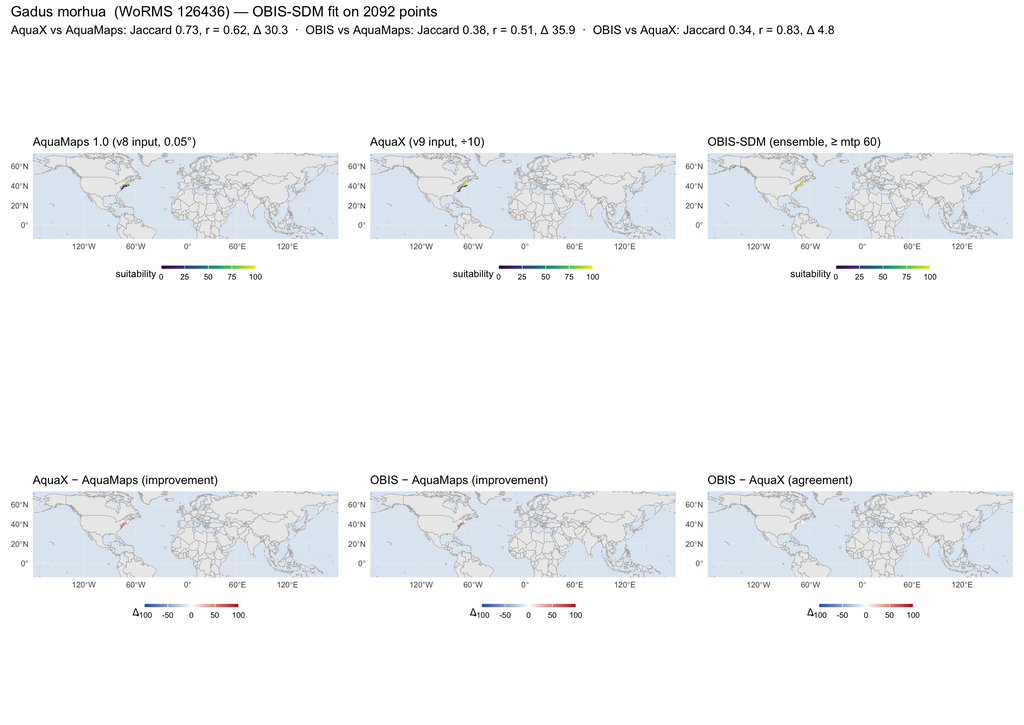

### 1.2 Acropora palmata

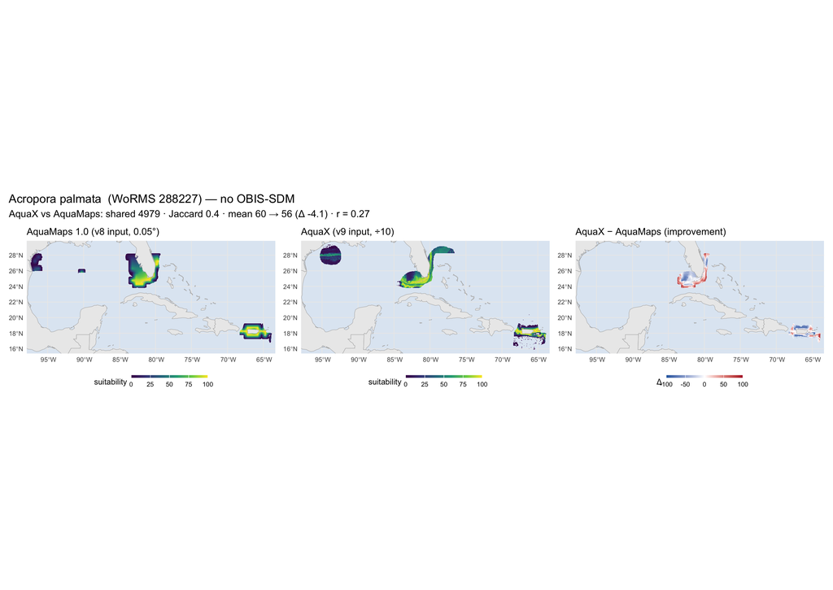

### 1.3 Thunnus thynnus

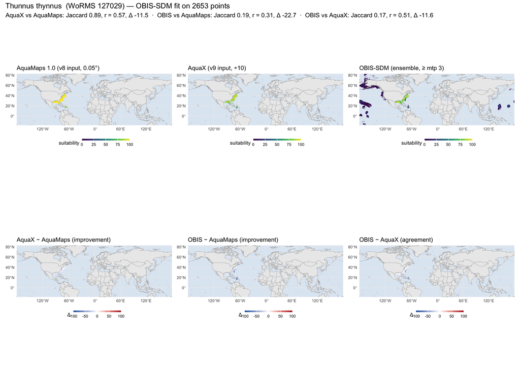

### 1.4 Lutjanus campechanus

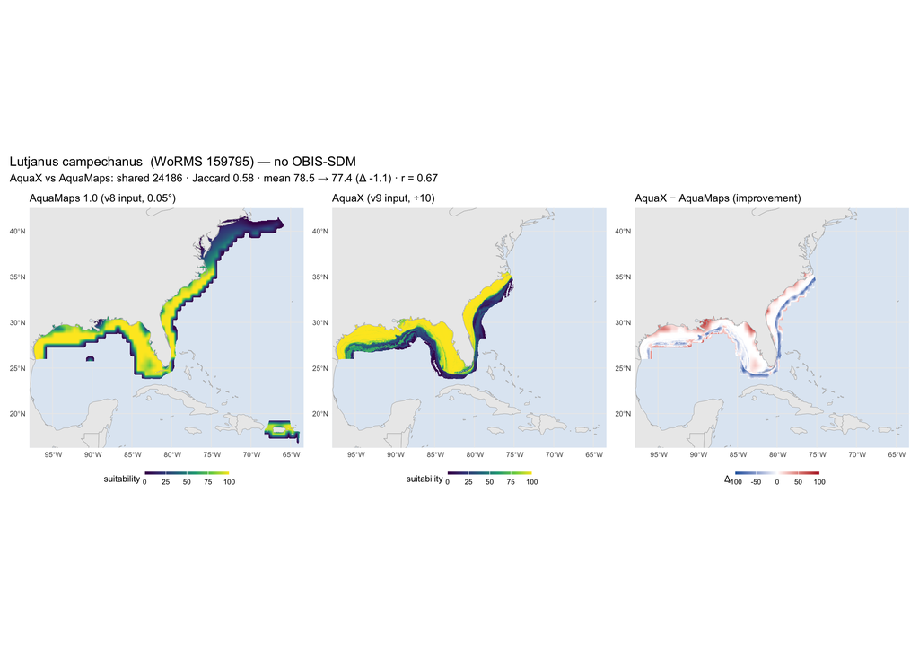

### 1.5 Hippoglossus stenolepis

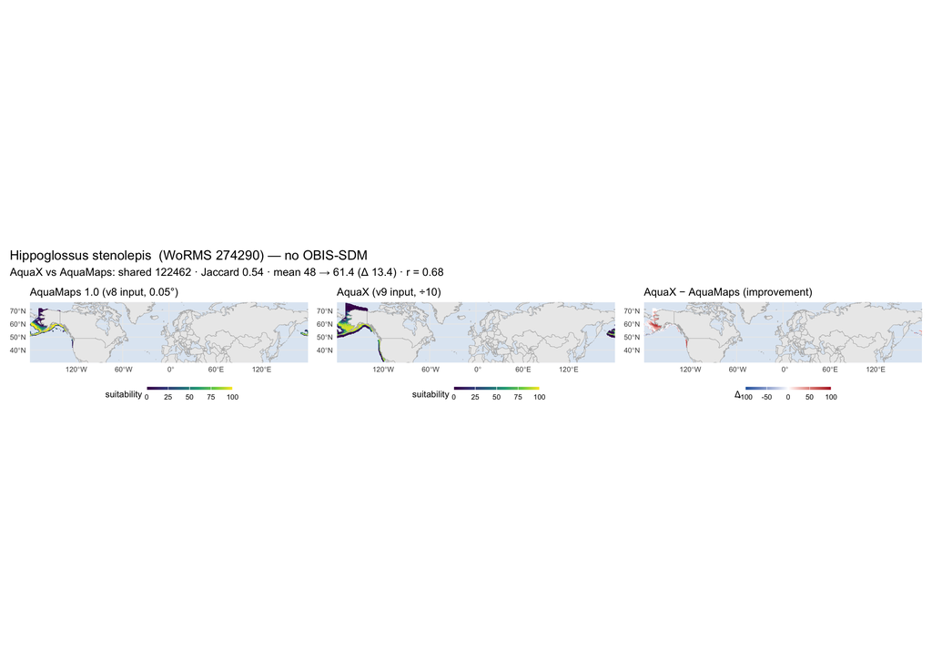

### 1.6 Acanthostepheia malmgreni

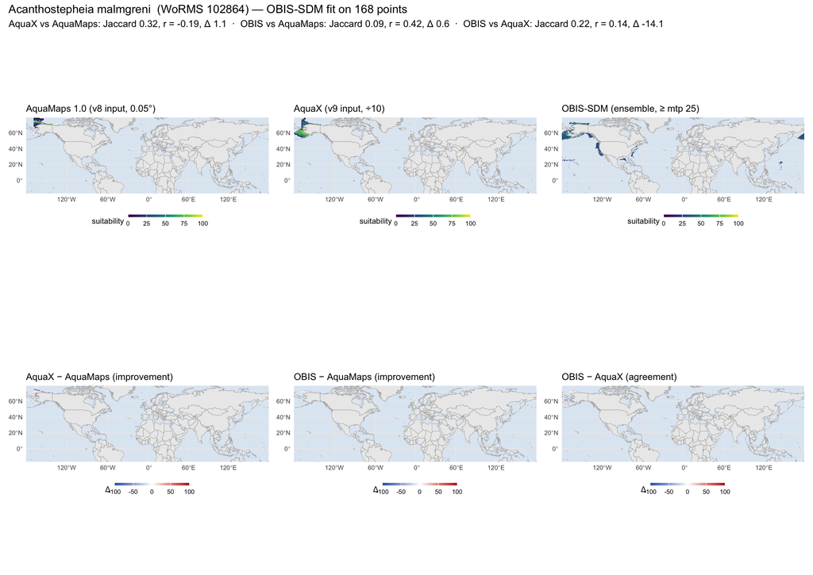

### 1.7 Caretta caretta

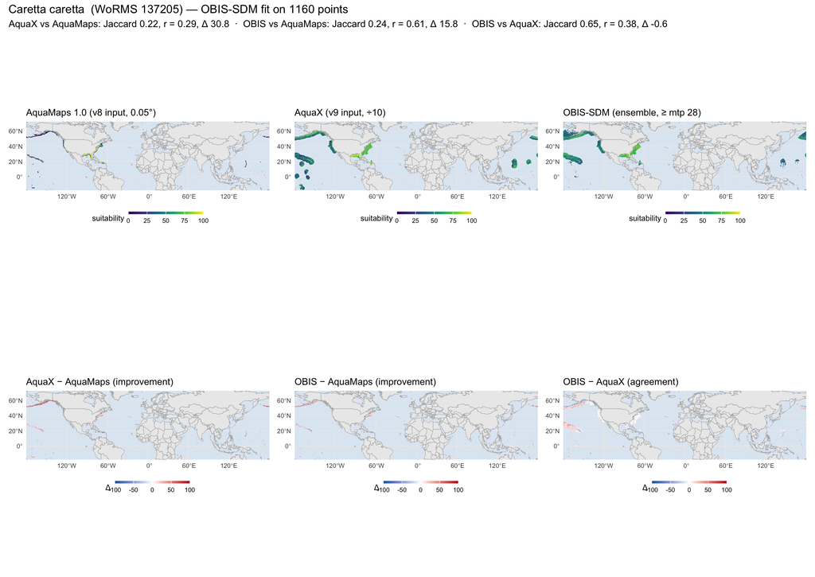

### 1.8 Homarus americanus

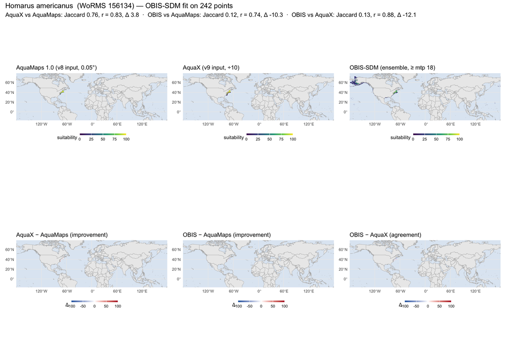

### 1.9 Odobenus rosmarus

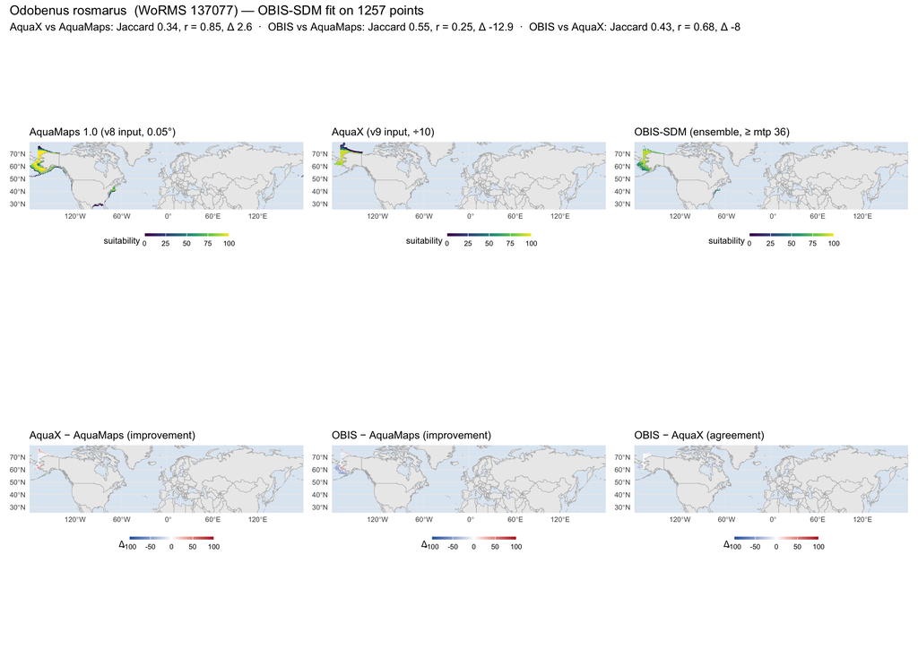

### 1.10 Megaptera novaeangliae

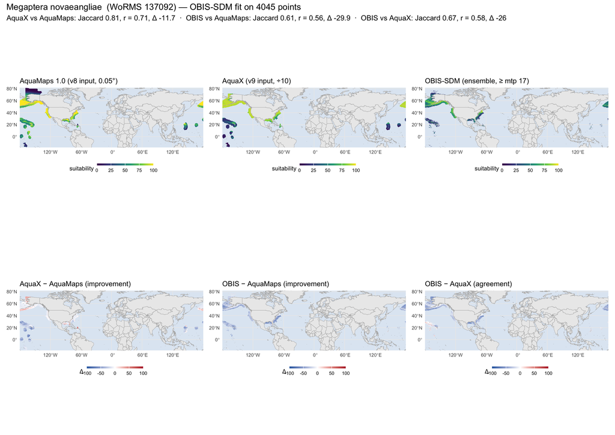

### 1.11 Tmetonyx cicada

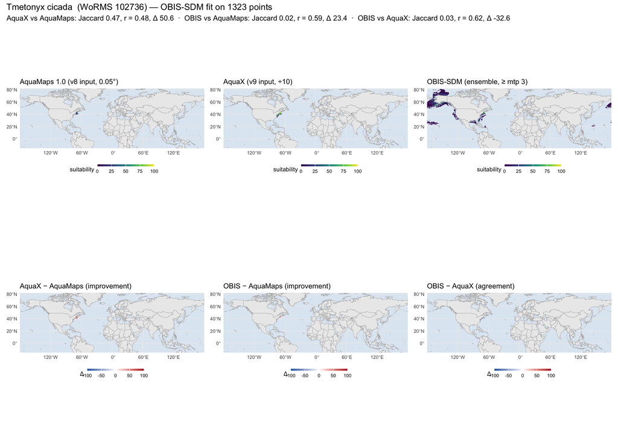

## 2 Summary of the examples

```r
st <- bind_rows(all_stats)
kable(st |> select(species, n_am, n_ax, n_ob, starts_with("jaccard"), starts_with("cor"), starts_with("delta")),
      caption = "Computed on the cells where both models of a pair have a value (inside the AquaX mask). Suffix ax_am = AquaX vs AquaMaps 1.0, ob_am = OBIS-SDM vs AquaMaps 1.0 (improvement), ob_ax = OBIS-SDM vs AquaX (agreement). delta = mean of the later model − the earlier on the [0,100] scale; Jaccard = footprint overlap; cor = Pearson r on shared cells.")
```

Computed on the cells where both models of a pair have a value (inside the AquaX mask). Suffix ax_am = AquaX vs AquaMaps 1.0, ob_am = OBIS-SDM vs AquaMaps 1.0 (improvement), ob_ax = OBIS-SDM vs AquaX (agreement). delta = mean of the later model − the earlier on the [0,100] scale; Jaccard = footprint overlap; cor = Pearson r on shared cells.

| species | n_am | n_ax | n_ob | jaccard_ax_am | jaccard_ob_am | jaccard_ob_ax | cor_ax_am | cor_ob_am | cor_ob_ax | delta_ax_am | delta_ob_am | delta_ob_ax |
| --- | --- | --- | --- | --- | --- | --- | --- | --- | --- | --- | --- | --- |
| Gadus morhua | 12915 | 17336 | 27331 | 0.73 | 0.38 | 0.34 | 0.62 | 0.51 | 0.83 | 30.3 | 35.9 | 4.8 |
| Acropora palmata | 8550 | 8928 | NA | 0.40 | NA | NA | 0.27 | NA | NA | -4.1 | NA | NA |
| Thunnus thynnus | 80367 | 71397 | 431262 | 0.89 | 0.19 | 0.17 | 0.57 | 0.31 | 0.51 | -11.5 | -22.7 | -11.6 |
| Lutjanus campechanus | 37006 | 28780 | NA | 0.58 | NA | NA | 0.67 | NA | NA | -1.1 | NA | NA |
| Hippoglossus stenolepis | 126376 | 221467 | NA | 0.54 | NA | NA | 0.68 | NA | NA | 13.4 | NA | NA |
| Acanthostepheia malmgreni | 60653 | 100437 | 185667 | 0.32 | 0.09 | 0.22 | -0.19 | 0.42 | 0.14 | 1.1 | 0.6 | -14.1 |
| Caretta caretta | 113379 | 411569 | 390536 | 0.22 | 0.24 | 0.65 | 0.29 | 0.61 | 0.38 | 30.8 | 15.8 | -0.6 |
| Homarus americanus | 13715 | 17815 | 109540 | 0.76 | 0.12 | 0.13 | 0.83 | 0.74 | 0.88 | 3.8 | -10.3 | -12.1 |
| Odobenus rosmarus | 138855 | 66242 | 78554 | 0.34 | 0.55 | 0.43 | 0.85 | 0.25 | 0.68 | 2.6 | -12.9 | -8.0 |
| Megaptera novaeangliae | 632612 | 511040 | 386942 | 0.81 | 0.61 | 0.67 | 0.71 | 0.56 | 0.58 | -11.7 | -29.9 | -26.0 |
| Tmetonyx cicada | 6632 | 14031 | 353901 | 0.47 | 0.02 | 0.03 | 0.48 | 0.59 | 0.62 | 50.6 | 23.4 | -32.6 |

```r
kable(st |> select(species, starts_with("n_shared"), starts_with("mean")),
      caption = "Shared-cell counts and mean suitability per pair (mean_a = earlier model, mean_b = later model).")
```

Shared-cell counts and mean suitability per pair (mean_a = earlier model, mean_b = later model).

| species | n_shared_ax_am | n_shared_ob_am | n_shared_ob_ax | mean_a_ax_am | mean_b_ax_am | mean_a_ob_am | mean_b_ob_am | mean_a_ob_ax | mean_b_ob_ax |
| --- | --- | --- | --- | --- | --- | --- | --- | --- | --- |
| Gadus morhua | 12795 | 11073 | 11228 | 49.4 | 79.7 | 55.3 | 91.2 | 85.9 | 90.7 |
| Acropora palmata | 4979 | NA | NA | 60.0 | 56.0 | NA | NA | NA | NA |
| Thunnus thynnus | 71397 | 80367 | 71397 | 96.9 | 85.4 | 96.5 | 73.8 | 85.4 | 73.7 |
| Lutjanus campechanus | 24186 | NA | NA | 78.5 | 77.4 | NA | NA | NA | NA |
| Hippoglossus stenolepis | 122462 | NA | NA | 48.0 | 61.4 | NA | NA | NA | NA |
| Acanthostepheia malmgreni | 39289 | 20805 | 51698 | 40.4 | 41.5 | 42.5 | 43.1 | 54.9 | 40.8 |
| Caretta caretta | 94190 | 97272 | 316897 | 38.0 | 68.8 | 42.9 | 58.8 | 56.1 | 55.5 |
| Homarus americanus | 13567 | 13223 | 14634 | 72.5 | 76.4 | 74.5 | 64.2 | 71.9 | 59.8 |
| Odobenus rosmarus | 52343 | 77511 | 43837 | 77.6 | 80.2 | 86.0 | 73.0 | 88.7 | 80.6 |
| Megaptera novaeangliae | 510999 | 386942 | 360610 | 75.5 | 63.8 | 82.0 | 52.1 | 77.9 | 51.9 |
| Tmetonyx cicada | 6579 | 6325 | 10911 | 19.5 | 70.1 | 20.1 | 43.5 | 64.2 | 31.7 |

```r
dbDisconnect(con, shutdown = TRUE)
```